# Cell Type Diversity Statistic: An entropy-based metric to compare overall cell type composition across samples

Tanya Karagiannis, Stefano Monti, Paola Sebastiani

# Introduction

The Cell Type Diversity Statistic is an entropy-based score to measure and assess the overall cell type composition across samples from single cell transcriptomic datasets.

Install the CTDS.score function by cloning the github repository and load the function in R.

```r
source('./CTDS/R/CTDS_function.R')
```

# Usage

We demonstrate the implementation of this method on cell type composition level data from three single cell RNA-seq datasets of aging and extreme old age. In this example, we apply the cell type diversity statistic on the cell type proportions per sample and compare differences in cell type diversity statistic between four age groups across the human lifespan to assess overall cell type composition changes in aging and extreme old age.

Load libraries

```r
suppressMessages(c(library(tidyverse),
library(hablar),
library(Seurat),
library(SingleCellExperiment),
library(knitr),
library(kableExtra),
library(patchwork)
))
```

[output not shown]

[output cut: 46 more lines]

Load integrated single cell RNA-seq datasets of PBMCs from aging and extreme old age individuals

```r
pbmc.combined <- readRDS(file = "./Data/pbmc.combined.rds")
```

## Creating matrix of cell type proportions

Create table of cell type proportions per sample (samples v. cell types) from Seurat object.

```r
ct_prop <- prop.table(table("sample.ID" = pbmc.combined@meta.data$sample.ID,
                            "cell.type" = pbmc.combined@meta.data$ct.consensus),
                            margin = 1)

kable(ct_prop, caption = paste0("cell type proportions per sample"),"html") %>% kable_styling("striped") %>% scroll_box(width = "100%",height = "300px")
```

cell type proportions per sample

|  | CD4 T NonCytotoxic | CD4 T Cytotoxic | CD8 T Cytotoxic | T Gamma Delta | Natural Killer | B Naive | B Memory | Plasma | CD14 Mono | CD16 Mono | Myeloid DC | Plasmacytoid DC |
| --- | --- | --- | --- | --- | --- | --- | --- | --- | --- | --- | --- | --- |
| CT1 | 0.5878256 | 0.0654149 | 0.0060569 | 0.0021199 | 0.0533010 | 0.0563295 | 0.0445185 | 0.0009085 | 0.1387038 | 0.0299818 | 0.0109025 | 0.0039370 |
| CT2 | 0.2720291 | 0.0309216 | 0.0078820 | 0.0115198 | 0.3623686 | 0.1141876 | 0.0131366 | 0.0010105 | 0.1077203 | 0.0697251 | 0.0058610 | 0.0036378 |
| CT3 | 0.3430799 | 0.0269006 | 0.0101365 | 0.0062378 | 0.2444444 | 0.2077973 | 0.0382066 | 0.0023392 | 0.0982456 | 0.0167641 | 0.0031189 | 0.0027290 |
| CT4 | 0.3814271 | 0.0346275 | 0.0758132 | 0.0225603 | 0.0724029 | 0.1694648 | 0.0453830 | 0.0041973 | 0.1587093 | 0.0246590 | 0.0081322 | 0.0026233 |
| CT5 | 0.4526343 | 0.0441215 | 0.0368544 | 0.0046717 | 0.1095250 | 0.0573579 | 0.0376330 | 0.0031145 | 0.1899818 | 0.0438619 | 0.0176486 | 0.0025954 |
| ILO_H_1876 | 0.3426052 | 0.0027137 | 0.2313433 | 0.0000000 | 0.1139756 | 0.0427408 | 0.0257802 | 0.0000000 | 0.1960651 | 0.0149254 | 0.0156038 | 0.0142469 |
| ILO_H_1925 | 0.2465181 | 0.0584958 | 0.1838440 | 0.0000000 | 0.2493036 | 0.0160167 | 0.0111421 | 0.0000000 | 0.1887187 | 0.0362117 | 0.0048747 | 0.0048747 |
| ILO_H_3168 | 0.3031401 | 0.0809179 | 0.2940821 | 0.0000000 | 0.0785024 | 0.0102657 | 0.0138889 | 0.0000000 | 0.1944444 | 0.0144928 | 0.0072464 | 0.0030193 |
| ILO_H_5893 | 0.1221719 | 0.0040221 | 0.0341880 | 0.0000000 | 0.1352438 | 0.0015083 | 0.0050277 | 0.0000000 | 0.6792358 | 0.0085470 | 0.0060332 | 0.0040221 |
| ILO_H_6384 | 0.4233010 | 0.0106796 | 0.1252427 | 0.0000000 | 0.2402913 | 0.0087379 | 0.0077670 | 0.0000000 | 0.1436893 | 0.0252427 | 0.0101942 | 0.0048544 |
| ILO_H_7983 | 0.2634731 | 0.1801851 | 0.2302667 | 0.0000000 | 0.0958084 | 0.0059880 | 0.0430049 | 0.0000000 | 0.1567774 | 0.0059880 | 0.0146979 | 0.0038106 |
| ILO_H_8163 | 0.3185299 | 0.0117407 | 0.2705462 | 0.0000000 | 0.2628892 | 0.0148035 | 0.0081674 | 0.0000000 | 0.0913731 | 0.0071465 | 0.0066360 | 0.0081674 |
| ILO_H_8507 | 0.0247366 | 0.0774164 | 0.4791571 | 0.0000000 | 0.0925332 | 0.0238204 | 0.0087036 | 0.0000000 | 0.2556115 | 0.0242785 | 0.0105360 | 0.0032066 |
| ILO_H_8657 | 0.2426471 | 0.0311086 | 0.2878959 | 0.0000000 | 0.2443439 | 0.0022624 | 0.0062217 | 0.0000000 | 0.1193439 | 0.0469457 | 0.0164027 | 0.0028281 |
| s1 | 0.5119306 | 0.0000000 | 0.1822126 | 0.0000000 | 0.1887202 | 0.0303688 | 0.0065076 | 0.0021692 | 0.0498915 | 0.0151844 | 0.0043384 | 0.0086768 |
| s10 | 0.6230088 | 0.0000000 | 0.0991150 | 0.0000000 | 0.0619469 | 0.0442478 | 0.0283186 | 0.0017699 | 0.1079646 | 0.0159292 | 0.0106195 | 0.0070796 |
| s11 | 0.6948276 | 0.0000000 | 0.0655172 | 0.0000000 | 0.0879310 | 0.0258621 | 0.0172414 | 0.0034483 | 0.0862069 | 0.0000000 | 0.0103448 | 0.0086207 |
| s12 | 0.5050349 | 0.0000000 | 0.1231603 | 0.0000000 | 0.2199845 | 0.0139427 | 0.0030984 | 0.0069713 | 0.0728118 | 0.0402789 | 0.0085205 | 0.0061967 |
| s13 | 0.6230366 | 0.0000000 | 0.0654450 | 0.0000000 | 0.0602094 | 0.0052356 | 0.0157068 | 0.0104712 | 0.2120419 | 0.0052356 | 0.0000000 | 0.0026178 |
| s14 | 0.5996785 | 0.0000000 | 0.0643087 | 0.0000000 | 0.0980707 | 0.0209003 | 0.0096463 | 0.0000000 | 0.1639871 | 0.0176849 | 0.0209003 | 0.0048232 |
| s15 | 0.5442671 | 0.0000000 | 0.1596517 | 0.0000000 | 0.1001451 | 0.0391872 | 0.0087083 | 0.0000000 | 0.0986938 | 0.0304790 | 0.0087083 | 0.0101597 |
| s16 | 0.5073099 | 0.0000000 | 0.2894737 | 0.0000000 | 0.1023392 | 0.0190058 | 0.0146199 | 0.0000000 | 0.0497076 | 0.0087719 | 0.0058480 | 0.0029240 |
| s17 | 0.5333333 | 0.0000000 | 0.1437500 | 0.0000000 | 0.1562500 | 0.0125000 | 0.0125000 | 0.0020833 | 0.0770833 | 0.0291667 | 0.0229167 | 0.0104167 |
| s18 | 0.5904139 | 0.0000000 | 0.1633987 | 0.0000000 | 0.1263617 | 0.0130719 | 0.0043573 | 0.0021786 | 0.0479303 | 0.0370370 | 0.0108932 | 0.0043573 |
| s19 | 0.6699029 | 0.0000000 | 0.1601942 | 0.0000000 | 0.0776699 | 0.0024272 | 0.0145631 | 0.0000000 | 0.0582524 | 0.0072816 | 0.0097087 | 0.0000000 |
| s2 | 0.6370236 | 0.0000000 | 0.0871143 | 0.0000000 | 0.1542650 | 0.0290381 | 0.0090744 | 0.0000000 | 0.0580762 | 0.0145191 | 0.0108893 | 0.0000000 |
| s20 | 0.2926829 | 0.0000000 | 0.3487805 | 0.0000000 | 0.1512195 | 0.0219512 | 0.0146341 | 0.0000000 | 0.1195122 | 0.0439024 | 0.0048780 | 0.0024390 |
| s21 | 0.4229323 | 0.0000000 | 0.3402256 | 0.0000000 | 0.1522556 | 0.0244361 | 0.0075188 | 0.0000000 | 0.0281955 | 0.0225564 | 0.0000000 | 0.0018797 |
| s22 | 0.4456869 | 0.0000000 | 0.1741214 | 0.0000000 | 0.1565495 | 0.0335463 | 0.0127796 | 0.0015974 | 0.1246006 | 0.0239617 | 0.0159744 | 0.0111821 |
| s23 | 0.6351351 | 0.0000000 | 0.0810811 | 0.0000000 | 0.0990991 | 0.0608108 | 0.0180180 | 0.0000000 | 0.0878378 | 0.0090090 | 0.0067568 | 0.0022523 |
| s24 | 0.4920213 | 0.0000000 | 0.1835106 | 0.0000000 | 0.1196809 | 0.0319149 | 0.0159574 | 0.0026596 | 0.0851064 | 0.0319149 | 0.0106383 | 0.0265957 |
| s25 | 0.4827586 | 0.0000000 | 0.2216749 | 0.0000000 | 0.0738916 | 0.0344828 | 0.0311987 | 0.0049261 | 0.1346470 | 0.0016420 | 0.0082102 | 0.0065681 |
| s26 | 0.5763889 | 0.0000000 | 0.0787037 | 0.0000000 | 0.1388889 | 0.0208333 | 0.0069444 | 0.0000000 | 0.1388889 | 0.0069444 | 0.0231481 | 0.0092593 |
| s27 | 0.6840731 | 0.0000000 | 0.0861619 | 0.0000000 | 0.0678851 | 0.0208877 | 0.0287206 | 0.0026110 | 0.0939948 | 0.0026110 | 0.0130548 | 0.0000000 |
| s28 | 0.3583062 | 0.0000000 | 0.0488599 | 0.0000000 | 0.2671010 | 0.0032573 | 0.0065147 | 0.0000000 | 0.1986971 | 0.0716612 | 0.0293160 | 0.0162866 |
| s29 | 0.4989562 | 0.0000000 | 0.2964509 | 0.0000000 | 0.0542797 | 0.0146138 | 0.0104384 | 0.0000000 | 0.0918580 | 0.0208768 | 0.0020877 | 0.0104384 |
| s3 | 0.3438438 | 0.0000000 | 0.4774775 | 0.0000000 | 0.0900901 | 0.0135135 | 0.0030030 | 0.0000000 | 0.0405405 | 0.0150150 | 0.0090090 | 0.0075075 |
| s30 | 0.5101523 | 0.0000000 | 0.1624365 | 0.0000000 | 0.1649746 | 0.0177665 | 0.0025381 | 0.0076142 | 0.1142132 | 0.0050761 | 0.0126904 | 0.0025381 |
| s31 | 0.5362998 | 0.0000000 | 0.0889930 | 0.0000000 | 0.1756440 | 0.0281030 | 0.0163934 | 0.0070258 | 0.1053864 | 0.0140515 | 0.0140515 | 0.0140515 |
| s32 | 0.6586453 | 0.0000000 | 0.1390374 | 0.0000000 | 0.0757576 | 0.0026738 | 0.0035651 | 0.0000000 | 0.0953654 | 0.0160428 | 0.0044563 | 0.0044563 |
| s33 | 0.5783582 | 0.0000000 | 0.0727612 | 0.0000000 | 0.1940299 | 0.0205224 | 0.0074627 | 0.0018657 | 0.0839552 | 0.0205224 | 0.0130597 | 0.0074627 |
| s34 | 0.5080645 | 0.0000000 | 0.2298387 | 0.0000000 | 0.0846774 | 0.0000000 | 0.0000000 | 0.0201613 | 0.0967742 | 0.0443548 | 0.0161290 | 0.0000000 |
| s35 | 0.3897764 | 0.0000000 | 0.1341853 | 0.0000000 | 0.2971246 | 0.0159744 | 0.0191693 | 0.0000000 | 0.1309904 | 0.0095847 | 0.0031949 | 0.0000000 |
| s36 | 0.6666667 | 0.0000000 | 0.0862745 | 0.0000000 | 0.0313725 | 0.0823529 | 0.0235294 | 0.0000000 | 0.0745098 | 0.0196078 | 0.0117647 | 0.0039216 |
| s37 | 0.5670290 | 0.0000000 | 0.1086957 | 0.0000000 | 0.1068841 | 0.0253623 | 0.0090580 | 0.0000000 | 0.1177536 | 0.0362319 | 0.0271739 | 0.0018116 |
| s38 | 0.6588235 | 0.0000000 | 0.0776471 | 0.0000000 | 0.1388235 | 0.0423529 | 0.0188235 | 0.0023529 | 0.0376471 | 0.0094118 | 0.0141176 | 0.0000000 |
| s39 | 0.7425968 | 0.0000000 | 0.0706150 | 0.0000000 | 0.0797267 | 0.0205011 | 0.0068337 | 0.0000000 | 0.0592255 | 0.0091116 | 0.0068337 | 0.0045558 |
| s4 | 0.5047438 | 0.0000000 | 0.2732448 | 0.0000000 | 0.0910816 | 0.0436433 | 0.0113852 | 0.0018975 | 0.0626186 | 0.0056926 | 0.0056926 | 0.0000000 |
| s40 | 0.5662949 | 0.0000000 | 0.1449814 | 0.0000000 | 0.1920694 | 0.0074349 | 0.0185874 | 0.0086741 | 0.0309789 | 0.0049566 | 0.0148699 | 0.0111524 |
| s41 | 0.6000000 | 0.0000000 | 0.1411765 | 0.0000000 | 0.0810458 | 0.0209150 | 0.0052288 | 0.0026144 | 0.1045752 | 0.0287582 | 0.0143791 | 0.0013072 |
| s42 | 0.5165877 | 0.0000000 | 0.0876777 | 0.0000000 | 0.1066351 | 0.0023697 | 0.0047393 | 0.0023697 | 0.1966825 | 0.0402844 | 0.0308057 | 0.0118483 |
| s43 | 0.6126126 | 0.0000000 | 0.1291291 | 0.0000000 | 0.0960961 | 0.0300300 | 0.0180180 | 0.0030030 | 0.0360360 | 0.0180180 | 0.0390390 | 0.0180180 |
| s44 | 0.5072993 | 0.0000000 | 0.1423358 | 0.0000000 | 0.0839416 | 0.0802920 | 0.0328467 | 0.0000000 | 0.1277372 | 0.0145985 | 0.0109489 | 0.0000000 |
| s45 | 0.6003617 | 0.0000000 | 0.1301989 | 0.0000000 | 0.1482821 | 0.0253165 | 0.0415913 | 0.0018083 | 0.0361664 | 0.0018083 | 0.0054250 | 0.0090416 |
| s5 | 0.6428571 | 0.0000000 | 0.2412698 | 0.0000000 | 0.0285714 | 0.0190476 | 0.0047619 | 0.0047619 | 0.0285714 | 0.0206349 | 0.0047619 | 0.0047619 |
| s6 | 0.3808777 | 0.0000000 | 0.3213166 | 0.0000000 | 0.1536050 | 0.0109718 | 0.0078370 | 0.0047022 | 0.0971787 | 0.0078370 | 0.0156740 | 0.0000000 |
| s7 | 0.6847545 | 0.0000000 | 0.1072351 | 0.0000000 | 0.0439276 | 0.0167959 | 0.0219638 | 0.0116279 | 0.0968992 | 0.0064599 | 0.0051680 | 0.0051680 |
| s8 | 0.5382716 | 0.0000000 | 0.1283951 | 0.0000000 | 0.1456790 | 0.0641975 | 0.0148148 | 0.0024691 | 0.0691358 | 0.0197531 | 0.0123457 | 0.0049383 |
| s9 | 0.5708661 | 0.0000000 | 0.1062992 | 0.0000000 | 0.1043307 | 0.0157480 | 0.0098425 | 0.0019685 | 0.1259843 | 0.0354331 | 0.0177165 | 0.0118110 |
| SC1 | 0.0461758 | 0.0344335 | 0.2883212 | 0.2459537 | 0.2192955 | 0.0042844 | 0.0114249 | 0.0009521 | 0.0966360 | 0.0480800 | 0.0036496 | 0.0007934 |
| SC2 | 0.0744631 | 0.1048754 | 0.1794952 | 0.0032921 | 0.4867534 | 0.0092491 | 0.0123844 | 0.0007838 | 0.1026807 | 0.0214767 | 0.0036056 | 0.0009406 |
| SC3 | 0.1134607 | 0.0538881 | 0.1630286 | 0.1739427 | 0.1625739 | 0.0245566 | 0.0443383 | 0.0038654 | 0.1934970 | 0.0520691 | 0.0079582 | 0.0068213 |
| SC4 | 0.2058174 | 0.0522828 | 0.1325479 | 0.0084683 | 0.2555228 | 0.0029455 | 0.0092047 | 0.0011046 | 0.3048601 | 0.0165685 | 0.0069956 | 0.0036819 |
| SC5 | 0.2539909 | 0.0593281 | 0.0883965 | 0.0233500 | 0.2239695 | 0.0500357 | 0.0254944 | 0.0057184 | 0.2363593 | 0.0147725 | 0.0140577 | 0.0045270 |
| SC6 | 0.1866690 | 0.1562281 | 0.3535689 | 0.0061232 | 0.0864241 | 0.0180196 | 0.0157453 | 0.0015745 | 0.1406578 | 0.0276417 | 0.0052484 | 0.0020994 |
| SC7 | 0.0428511 | 0.0315082 | 0.3299258 | 0.0023806 | 0.3575130 | 0.0056015 | 0.0100826 | 0.0005601 | 0.1782663 | 0.0287075 | 0.0089623 | 0.0036409 |

Create matrix of metadata information from Seurat object:

- sample ID (sample.ID)
- age based on the four age groups of the human lifespan (age.quartiles)
- scRNA-seq dataset of origin (batch)

```r
metadat <- pbmc.combined@meta.data %>%
            as_tibble() %>%
            dplyr::select(sample.ID, age.quartiles, batch) %>%
            dplyr::distinct()

kable(metadat, caption = paste0("metadata information"),"html") %>% kable_styling("striped") %>% scroll_box(width = "100%",height = "300px")
```

metadata information

| sample.ID | age.quartiles | batch |
| --- | --- | --- |
| s1 | Younger Age | NATGEN |
| s10 | Younger Age | NATGEN |
| s11 | Younger Age | NATGEN |
| s12 | Younger Age | NATGEN |
| s13 | Younger Age | NATGEN |
| s14 | Younger Age | NATGEN |
| s15 | Middle Age | NATGEN |
| s16 | Older Age | NATGEN |
| s17 | Middle Age | NATGEN |
| s18 | Middle Age | NATGEN |
| s19 | Middle Age | NATGEN |
| s2 | Middle Age | NATGEN |
| s20 | Older Age | NATGEN |
| s21 | Middle Age | NATGEN |
| s22 | Older Age | NATGEN |
| s23 | Middle Age | NATGEN |
| s24 | Younger Age | NATGEN |
| s25 | Younger Age | NATGEN |
| s26 | Younger Age | NATGEN |
| s27 | Older Age | NATGEN |
| s28 | Middle Age | NATGEN |
| s29 | Middle Age | NATGEN |
| s3 | Older Age | NATGEN |
| s30 | Middle Age | NATGEN |
| s31 | Middle Age | NATGEN |
| s32 | Older Age | NATGEN |
| s33 | Older Age | NATGEN |
| s34 | Middle Age | NATGEN |
| s35 | Middle Age | NATGEN |
| s36 | Middle Age | NATGEN |
| s37 | Younger Age | NATGEN |
| s38 | Older Age | NATGEN |
| s39 | Middle Age | NATGEN |
| s4 | Middle Age | NATGEN |
| s40 | Middle Age | NATGEN |
| s41 | Middle Age | NATGEN |
| s42 | Middle Age | NATGEN |
| s43 | Younger Age | NATGEN |
| s44 | Middle Age | NATGEN |
| s45 | Older Age | NATGEN |
| s5 | Older Age | NATGEN |
| s6 | Middle Age | NATGEN |
| s7 | Middle Age | NATGEN |
| s8 | Middle Age | NATGEN |
| s9 | Middle Age | NATGEN |
| SC1 | Extreme Old Age | PNAS |
| SC2 | Extreme Old Age | PNAS |
| SC3 | Extreme Old Age | PNAS |
| SC4 | Extreme Old Age | PNAS |
| SC5 | Extreme Old Age | PNAS |
| SC6 | Extreme Old Age | PNAS |
| SC7 | Extreme Old Age | PNAS |
| CT1 | Middle Age | PNAS |
| CT2 | Older Age | PNAS |
| CT3 | Older Age | PNAS |
| CT4 | Older Age | PNAS |
| CT5 | Older Age | PNAS |
| ILO_H_8163 | Younger Age | NECS |
| ILO_H_1876 | Middle Age | NECS |
| ILO_H_5893 | Extreme Old Age | NECS |
| ILO_H_8657 | Extreme Old Age | NECS |
| ILO_H_7983 | Extreme Old Age | NECS |
| ILO_H_6384 | Extreme Old Age | NECS |
| ILO_H_3168 | Extreme Old Age | NECS |
| ILO_H_8507 | Extreme Old Age | NECS |
| ILO_H_1925 | Extreme Old Age | NECS |

Bind data frames of cell type proportions and metadata information together

```r
normprop <- ct_prop %>%
           tibble::as_data_frame() %>%
           dplyr::rename("proportion" = n) %>%
           dplyr::full_join(metadat, by = "sample.ID") %>%
           hablar::convert(fct(cell.type))
kable(normprop, caption = paste0("cell type proportions with metadata information"),"html") %>% kable_styling("striped") %>% scroll_box(width = "100%",height = "300px")
```

cell type proportions with metadata information

| sample.ID | cell.type | proportion | age.quartiles | batch |
| --- | --- | --- | --- | --- |
| CT1 | CD4 T NonCytotoxic | 0.5878256 | Middle Age | PNAS |
| CT2 | CD4 T NonCytotoxic | 0.2720291 | Older Age | PNAS |
| CT3 | CD4 T NonCytotoxic | 0.3430799 | Older Age | PNAS |
| CT4 | CD4 T NonCytotoxic | 0.3814271 | Older Age | PNAS |
| CT5 | CD4 T NonCytotoxic | 0.4526343 | Older Age | PNAS |
| ILO_H_1876 | CD4 T NonCytotoxic | 0.3426052 | Middle Age | NECS |
| ILO_H_1925 | CD4 T NonCytotoxic | 0.2465181 | Extreme Old Age | NECS |
| ILO_H_3168 | CD4 T NonCytotoxic | 0.3031401 | Extreme Old Age | NECS |
| ILO_H_5893 | CD4 T NonCytotoxic | 0.1221719 | Extreme Old Age | NECS |
| ILO_H_6384 | CD4 T NonCytotoxic | 0.4233010 | Extreme Old Age | NECS |
| ILO_H_7983 | CD4 T NonCytotoxic | 0.2634731 | Extreme Old Age | NECS |
| ILO_H_8163 | CD4 T NonCytotoxic | 0.3185299 | Younger Age | NECS |
| ILO_H_8507 | CD4 T NonCytotoxic | 0.0247366 | Extreme Old Age | NECS |
| ILO_H_8657 | CD4 T NonCytotoxic | 0.2426471 | Extreme Old Age | NECS |
| s1 | CD4 T NonCytotoxic | 0.5119306 | Younger Age | NATGEN |
| s10 | CD4 T NonCytotoxic | 0.6230088 | Younger Age | NATGEN |
| s11 | CD4 T NonCytotoxic | 0.6948276 | Younger Age | NATGEN |
| s12 | CD4 T NonCytotoxic | 0.5050349 | Younger Age | NATGEN |
| s13 | CD4 T NonCytotoxic | 0.6230366 | Younger Age | NATGEN |
| s14 | CD4 T NonCytotoxic | 0.5996785 | Younger Age | NATGEN |
| s15 | CD4 T NonCytotoxic | 0.5442671 | Middle Age | NATGEN |
| s16 | CD4 T NonCytotoxic | 0.5073099 | Older Age | NATGEN |
| s17 | CD4 T NonCytotoxic | 0.5333333 | Middle Age | NATGEN |
| s18 | CD4 T NonCytotoxic | 0.5904139 | Middle Age | NATGEN |
| s19 | CD4 T NonCytotoxic | 0.6699029 | Middle Age | NATGEN |
| s2 | CD4 T NonCytotoxic | 0.6370236 | Middle Age | NATGEN |
| s20 | CD4 T NonCytotoxic | 0.2926829 | Older Age | NATGEN |
| s21 | CD4 T NonCytotoxic | 0.4229323 | Middle Age | NATGEN |
| s22 | CD4 T NonCytotoxic | 0.4456869 | Older Age | NATGEN |
| s23 | CD4 T NonCytotoxic | 0.6351351 | Middle Age | NATGEN |

[output cut: 762 more lines]

Visualize cell type proportions for all samples grouped by age group.

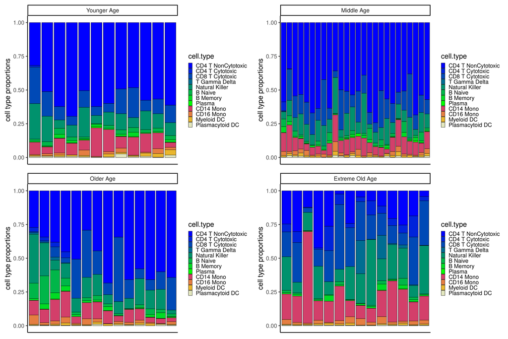

```r
normprop$cell.type <- factor(normprop$cell.type, levels = levels(pbmc.combined@meta.data$ct.consensus))

#generate bar plots
age.groups <- levels(normprop$age.quartiles)

plot.prop <- lapply(1:length(age.groups), function(x){
  age.dat <- normprop %>% dplyr::filter(age.quartiles == age.groups[x])

  require(colorspace)
  plot.res <- ggplot(age.dat, aes(interaction(sample.ID, age.quartiles), proportion)) +
              geom_bar(aes(group = cell.type, fill = cell.type), stat="identity", position = "stack", color = "black") +
              scale_fill_manual(values =  c(colorRamps::blue2green(8), colorspace::heat_hcl(4))) +
              theme_classic(base_size = 30) +
                theme(axis.line=element_line()) +
                facet_wrap(~ age.quartiles) +
              ylab("cell type proportions") +
              theme(axis.title.x=element_blank(),
                    axis.text.x=element_blank(),
                    axis.ticks.x=element_blank())

 return(plot.res)
})
#plot bar plots together using patchwork
require(patchwork)
plot.prop[[1]] + plot.prop[[2]] + plot.prop[[3]] + plot.prop[[4]] + patchwork::plot_layout(ncol = 2)
```

## Calculate cell type diversity statistic for each sample

### Matrix, Table Implementaion

- Run CTDS function with matrix or table of cell type proportions per sample and calculate the cell type diversity statistic per sample.

```r
div.res <- CTDS.score(as.matrix(ct_prop))

kable(div.res, caption = paste0("cell type diversity statistic"),"html") %>% kable_styling("striped") %>% scroll_box(width = "100%",height = "300px")
```

cell type diversity statistic

| sample.ID | statistic |
| --- | --- |
| CT1 | -0.4172380 |
| CT2 | -0.3130551 |
| CT3 | -0.3227648 |
| CT4 | -0.2524533 |
| CT5 | -0.3037315 |
| ILO_H_1876 | -0.3134750 |
| ILO_H_1925 | -0.2868899 |
| ILO_H_3168 | -0.3302075 |
| ILO_H_5893 | -0.5742800 |
| ILO_H_6384 | -0.3808173 |
| ILO_H_7983 | -0.2782703 |
| ILO_H_8163 | -0.3763803 |
| ILO_H_8507 | -0.3971573 |
| ILO_H_8657 | -0.3234873 |
| s1 | -0.4374735 |
| s10 | -0.4623939 |
| s11 | -0.5456697 |
| s12 | -0.4203554 |
| s13 | -0.5352641 |
| s14 | -0.4724663 |
| s15 | -0.4182549 |
| s16 | -0.4722598 |
| s17 | -0.4119405 |
| s18 | -0.4756977 |
| s19 | -0.5642182 |
| s2 | -0.5132218 |
| s20 | -0.3601187 |
| s21 | -0.4596367 |
| s22 | -0.3561257 |
| s23 | -0.4900073 |
| s24 | -0.3680532 |
| s25 | -0.4038263 |
| s26 | -0.4582489 |
| s27 | -0.5386984 |
| s28 | -0.3561874 |
| s29 | -0.4625709 |
| s3 | -0.4830223 |
| s30 | -0.4345928 |
| s31 | -0.4066312 |
| s32 | -0.5495137 |
| s33 | -0.4629534 |
| s34 | -0.4363918 |
| s35 | -0.4090750 |
| s36 | -0.5055243 |
| s37 | -0.4288584 |
| s38 | -0.5179197 |
| s39 | -0.6006255 |
| s4 | -0.4568418 |
| s40 | -0.4698985 |
| s41 | -0.4694854 |
| s42 | -0.4139382 |
| s43 | -0.4463402 |
| s44 | -0.3889330 |
| s45 | -0.4793184 |
| s5 | -0.5623103 |
| s6 | -0.4114043 |
| s7 | -0.5358028 |
| s8 | -0.4069051 |
| s9 | -0.4283717 |
| SC1 | -0.2863848 |
| SC2 | -0.3746918 |
| SC3 | -0.1571391 |
| SC4 | -0.3199692 |
| SC5 | -0.2299658 |
| SC6 | -0.2847948 |
| SC7 | -0.3788438 |

```r
#join with sample level metadata information
div.res <- CTDS.score(as.matrix(ct_prop), metadata = metadat)

kable(div.res, caption = paste0("cell type diversity statistic"),"html") %>% kable_styling("striped") %>% scroll_box(width = "100%",height = "300px")
```

cell type diversity statistic

| sample.ID | statistic | age.quartiles | batch |
| --- | --- | --- | --- |
| CT1 | -0.4172380 | Middle Age | PNAS |
| CT2 | -0.3130551 | Older Age | PNAS |
| CT3 | -0.3227648 | Older Age | PNAS |
| CT4 | -0.2524533 | Older Age | PNAS |
| CT5 | -0.3037315 | Older Age | PNAS |
| ILO_H_1876 | -0.3134750 | Middle Age | NECS |
| ILO_H_1925 | -0.2868899 | Extreme Old Age | NECS |
| ILO_H_3168 | -0.3302075 | Extreme Old Age | NECS |
| ILO_H_5893 | -0.5742800 | Extreme Old Age | NECS |
| ILO_H_6384 | -0.3808173 | Extreme Old Age | NECS |
| ILO_H_7983 | -0.2782703 | Extreme Old Age | NECS |
| ILO_H_8163 | -0.3763803 | Younger Age | NECS |
| ILO_H_8507 | -0.3971573 | Extreme Old Age | NECS |
| ILO_H_8657 | -0.3234873 | Extreme Old Age | NECS |
| s1 | -0.4374735 | Younger Age | NATGEN |
| s10 | -0.4623939 | Younger Age | NATGEN |
| s11 | -0.5456697 | Younger Age | NATGEN |
| s12 | -0.4203554 | Younger Age | NATGEN |
| s13 | -0.5352641 | Younger Age | NATGEN |
| s14 | -0.4724663 | Younger Age | NATGEN |
| s15 | -0.4182549 | Middle Age | NATGEN |
| s16 | -0.4722598 | Older Age | NATGEN |
| s17 | -0.4119405 | Middle Age | NATGEN |
| s18 | -0.4756977 | Middle Age | NATGEN |
| s19 | -0.5642182 | Middle Age | NATGEN |
| s2 | -0.5132218 | Middle Age | NATGEN |
| s20 | -0.3601187 | Older Age | NATGEN |
| s21 | -0.4596367 | Middle Age | NATGEN |
| s22 | -0.3561257 | Older Age | NATGEN |
| s23 | -0.4900073 | Middle Age | NATGEN |
| s24 | -0.3680532 | Younger Age | NATGEN |
| s25 | -0.4038263 | Younger Age | NATGEN |
| s26 | -0.4582489 | Younger Age | NATGEN |
| s27 | -0.5386984 | Older Age | NATGEN |
| s28 | -0.3561874 | Middle Age | NATGEN |
| s29 | -0.4625709 | Middle Age | NATGEN |
| s3 | -0.4830223 | Older Age | NATGEN |
| s30 | -0.4345928 | Middle Age | NATGEN |
| s31 | -0.4066312 | Middle Age | NATGEN |
| s32 | -0.5495137 | Older Age | NATGEN |
| s33 | -0.4629534 | Older Age | NATGEN |
| s34 | -0.4363918 | Middle Age | NATGEN |
| s35 | -0.4090750 | Middle Age | NATGEN |
| s36 | -0.5055243 | Middle Age | NATGEN |
| s37 | -0.4288584 | Younger Age | NATGEN |
| s38 | -0.5179197 | Older Age | NATGEN |
| s39 | -0.6006255 | Middle Age | NATGEN |
| s4 | -0.4568418 | Middle Age | NATGEN |
| s40 | -0.4698985 | Middle Age | NATGEN |
| s41 | -0.4694854 | Middle Age | NATGEN |
| s42 | -0.4139382 | Middle Age | NATGEN |
| s43 | -0.4463402 | Younger Age | NATGEN |
| s44 | -0.3889330 | Middle Age | NATGEN |
| s45 | -0.4793184 | Older Age | NATGEN |
| s5 | -0.5623103 | Older Age | NATGEN |
| s6 | -0.4114043 | Middle Age | NATGEN |
| s7 | -0.5358028 | Middle Age | NATGEN |
| s8 | -0.4069051 | Middle Age | NATGEN |
| s9 | -0.4283717 | Middle Age | NATGEN |
| SC1 | -0.2863848 | Extreme Old Age | PNAS |
| SC2 | -0.3746918 | Extreme Old Age | PNAS |
| SC3 | -0.1571391 | Extreme Old Age | PNAS |
| SC4 | -0.3199692 | Extreme Old Age | PNAS |
| SC5 | -0.2299658 | Extreme Old Age | PNAS |
| SC6 | -0.2847948 | Extreme Old Age | PNAS |
| SC7 | -0.3788438 | Extreme Old Age | PNAS |

### SingleCellExperiment Object, Seurat Object Implementation

- Run CTDS function with Seurat/SingleCellExperiment Object to calculate normalized cell type proportions per sample and calculate the cell type diversity statistic per sample.

```r
#Run CTDS function
div.res <- CTDS.score(pbmc.combined, sample = "sample.ID", cell.type = "ct.consensus", metadata = metadat)

kable(div.res, caption = paste0("cell type diversity statistic"),"html") %>% kable_styling("striped") %>% scroll_box(width = "100%",height = "300px")
```

cell type diversity statistic

| sample.ID | statistic | age.quartiles | batch |
| --- | --- | --- | --- |
| CT1 | -0.4172380 | Middle Age | PNAS |
| CT2 | -0.3130551 | Older Age | PNAS |
| CT3 | -0.3227648 | Older Age | PNAS |
| CT4 | -0.2524533 | Older Age | PNAS |
| CT5 | -0.3037315 | Older Age | PNAS |
| ILO_H_1876 | -0.3134750 | Middle Age | NECS |
| ILO_H_1925 | -0.2868899 | Extreme Old Age | NECS |
| ILO_H_3168 | -0.3302075 | Extreme Old Age | NECS |
| ILO_H_5893 | -0.5742800 | Extreme Old Age | NECS |
| ILO_H_6384 | -0.3808173 | Extreme Old Age | NECS |
| ILO_H_7983 | -0.2782703 | Extreme Old Age | NECS |
| ILO_H_8163 | -0.3763803 | Younger Age | NECS |
| ILO_H_8507 | -0.3971573 | Extreme Old Age | NECS |
| ILO_H_8657 | -0.3234873 | Extreme Old Age | NECS |
| s1 | -0.4374735 | Younger Age | NATGEN |
| s10 | -0.4623939 | Younger Age | NATGEN |
| s11 | -0.5456697 | Younger Age | NATGEN |
| s12 | -0.4203554 | Younger Age | NATGEN |
| s13 | -0.5352641 | Younger Age | NATGEN |
| s14 | -0.4724663 | Younger Age | NATGEN |
| s15 | -0.4182549 | Middle Age | NATGEN |
| s16 | -0.4722598 | Older Age | NATGEN |
| s17 | -0.4119405 | Middle Age | NATGEN |
| s18 | -0.4756977 | Middle Age | NATGEN |
| s19 | -0.5642182 | Middle Age | NATGEN |
| s2 | -0.5132218 | Middle Age | NATGEN |
| s20 | -0.3601187 | Older Age | NATGEN |
| s21 | -0.4596367 | Middle Age | NATGEN |
| s22 | -0.3561257 | Older Age | NATGEN |
| s23 | -0.4900073 | Middle Age | NATGEN |
| s24 | -0.3680532 | Younger Age | NATGEN |
| s25 | -0.4038263 | Younger Age | NATGEN |
| s26 | -0.4582489 | Younger Age | NATGEN |
| s27 | -0.5386984 | Older Age | NATGEN |
| s28 | -0.3561874 | Middle Age | NATGEN |
| s29 | -0.4625709 | Middle Age | NATGEN |
| s3 | -0.4830223 | Older Age | NATGEN |
| s30 | -0.4345928 | Middle Age | NATGEN |
| s31 | -0.4066312 | Middle Age | NATGEN |
| s32 | -0.5495137 | Older Age | NATGEN |
| s33 | -0.4629534 | Older Age | NATGEN |
| s34 | -0.4363918 | Middle Age | NATGEN |
| s35 | -0.4090750 | Middle Age | NATGEN |
| s36 | -0.5055243 | Middle Age | NATGEN |
| s37 | -0.4288584 | Younger Age | NATGEN |
| s38 | -0.5179197 | Older Age | NATGEN |
| s39 | -0.6006255 | Middle Age | NATGEN |
| s4 | -0.4568418 | Middle Age | NATGEN |
| s40 | -0.4698985 | Middle Age | NATGEN |
| s41 | -0.4694854 | Middle Age | NATGEN |
| s42 | -0.4139382 | Middle Age | NATGEN |
| s43 | -0.4463402 | Younger Age | NATGEN |
| s44 | -0.3889330 | Middle Age | NATGEN |
| s45 | -0.4793184 | Older Age | NATGEN |
| s5 | -0.5623103 | Older Age | NATGEN |
| s6 | -0.4114043 | Middle Age | NATGEN |
| s7 | -0.5358028 | Middle Age | NATGEN |
| s8 | -0.4069051 | Middle Age | NATGEN |
| s9 | -0.4283717 | Middle Age | NATGEN |
| SC1 | -0.2863848 | Extreme Old Age | PNAS |
| SC2 | -0.3746918 | Extreme Old Age | PNAS |
| SC3 | -0.1571391 | Extreme Old Age | PNAS |
| SC4 | -0.3199692 | Extreme Old Age | PNAS |
| SC5 | -0.2299658 | Extreme Old Age | PNAS |
| SC6 | -0.2847948 | Extreme Old Age | PNAS |
| SC7 | -0.3788438 | Extreme Old Age | PNAS |

### Visualization and statistical tests of cell type diversity statistics

Visualizations and statistical tests to compare cell type diversity statistics between four age groups across the human lifespan: Younger (20-39), Middle Age (40-59), Older Age (60-89), and Extreme Old Age (100-119).

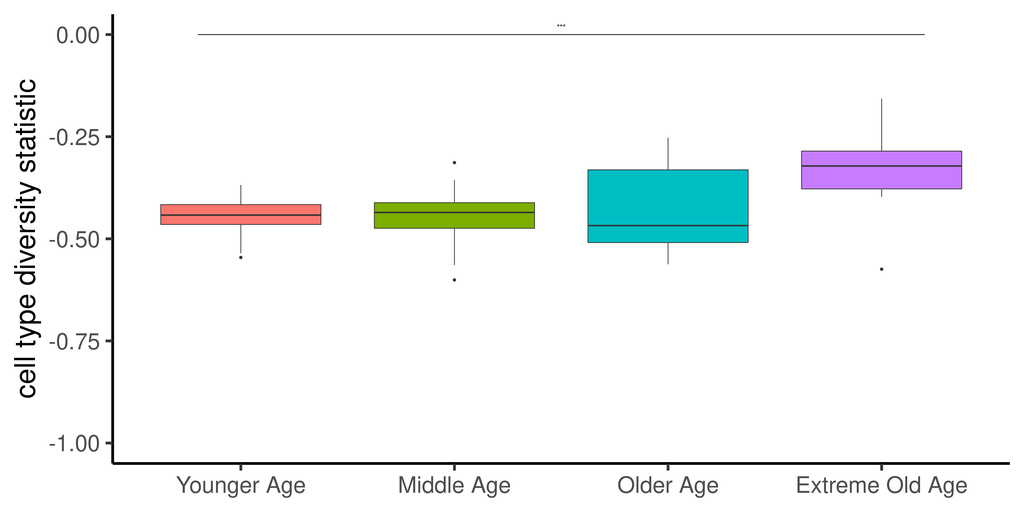

```r
plot.ctds <- ggplot(div.res, aes(age.quartiles, statistic)) +
              geom_boxplot(aes(fill = age.quartiles)) +
              theme_classic(base_size = 40) +
              theme(axis.line=element_line()) +
              ylim(-1, 0) +
  theme(axis.title.x=element_blank(),
        legend.position = "none") +
              ylab("cell type diversity statistic") +
              ggsignif::geom_signif(
    y_position = c(0), xmin = c(0.8), xmax = c(4.2),
    annotation = c("***"), tip_length = 0
  )
plot.ctds
```

Statistical tests

- Anova and T-test of cell type diversity statistics between the four age groups

```r
#anova to test if there is a significant difference in at least one age group
lm.model <- lm(statistic ~ age.quartiles, data = div.res)
anova(lm.model) %>% broom::tidy()
```

```
## # A tibble: 2 x 6
##   term             df sumsq  meansq statistic   p.value
##   <chr>         <int> <dbl>   <dbl>     <dbl>     <dbl>
## 1 age.quartiles     3 0.146 0.0487       7.70  0.000187
## 2 Residuals        62 0.392 0.00632     NA    NA
```

```r
#pairwise t-tests for multiple comparisons between the scores of age groups
pairwise.t.test(div.res$statistic, div.res$age.quartiles, p.adjust.method = "BH") %>% broom::tidy()
```

```
## # A tibble: 6 x 3
##   group1          group2       p.value
##   <chr>           <chr>          <dbl>
## 1 Middle Age      Younger Age 0.941
## 2 Older Age       Younger Age 0.641
## 3 Extreme Old Age Younger Age 0.00115
## 4 Older Age       Middle Age  0.623
## 5 Extreme Old Age Middle Age  0.000161
## 6 Extreme Old Age Older Age   0.00363
```